# CS102/CS103: Week 06 - Lists (V1.2)

Lecture notes for Week 6 of CS102/CS103, 2+3 November, 2022. (More will be added before Thursday). Dr Niall Madden, School of Mathematical and Statistical Sciences, University of Galway.

You can find these notes on

- Blackboard
- as HTML at: https://www.niallmadden.ie/2223-CS103
- Jupyter notebook on Binder https://mybinder.org/v2/gh/niallmadden/2223-cs103/main
- Both formats on Github: https://github.com/niallmadden/2223-cs103

*This notebook was written by Niall Madden, and uses some material by Tobias Rossmann, and Chapter 10 (Lists) of [Think Python](https://greenteapress.com/thinkpython2/html).*

## News:

### No lab this week

- **Did you submit your work for Lab 3?**
- Labs return next week (7-9 November).

### Jupyter

We are *still* working on out "Jupyter-in-the-cloud" solution. For now, continue to use https://jupyter.nuigalway.ie/ or https://jupyter.org/ or https://colab.research.google.com/ or other solution.

## Collections

Some of the Python **types** that we have encountered so far store a single value, include booleans, integers, floats, and functions

Python includes several types which can be used to hold **collections** of values. Strings are one such example: each string is a sequence of characters.

We also encountered **ranges**: `range(n)` "represents" the collection of integers from `0` to `n-1`.

Often, we need data types that store collections of things. They might represent, for example, vectors or matrices.

Or they could represent something that has multiple different components, such as a student record (name, ID number, address, programme. modules, ...)

The most important general collection (or compound) types in Python are:

- **Lists**: a list is a mutable (= changeable) ordered collection. Duplicates are allowed.
- **Tuples**: a tuple is an immutable ordered collection. Duplicates are allowed.
- **Sets**: a (Python) set is a mutable unordered collection without duplicates.
- **Dictionaries**: a dictionary is an unordered but indexed mutable collection without duplicate indices.

First we'll look at `list`s (Chapter 10 of the book), then `tuple`s (Chapter 11) and dictionaries (Chapter 12).

## Lists

- **A `list` is a sequence of values**. But, whereas a string is a sequence of characters, a list can be a sequence of any type.
- The values in a list are called *items* or *elements*.
- The list starts with `[`, ends with `]`, and items are separated by commas.

In this section, we'll learn

- What a list is
- How to create one
- Modifying items in a list
- Indexing and slicing
- How to traverse a list with a `for` loop
- Some functions/methods for operating on a list

## Making lists

### Making a list with `[` and `]`

The simplest way to create a list is using square backets, `[` and `]`, with a comma between elements.

```python
[0, 1, 2, 3, 4] # a list of integers
```

```
[0, 1, 2, 3, 4]
```

```python
['zero', 'one', 'two', 'three'] # a list of strings
```

```
['zero', 'one', 'two', 'three']
```

Usually, we assign a variable name to the list.

```python
my_favourite_numbers = [0, 4, 1024]
```

```python
print(f"{my_favourite_numbers}")
```

```
[0, 4, 1024]
```

### A list with different types of items

An item in a list can be just about anything. And items in a list can be of different types from each other. This list includes strings, an integer, a float, and a boolean.

```python
mixed_list = ["Sean Student", "1BS1", 22113344, 78.5, True]
print(mixed_list)
```

```
['Sean Student', '1BS1', 22113344, 78.5, True]
```

```python
type(mixed_list)
```

```
list
```

```python
type(mixed_list[2])
```

```
int
```

You can even make a list with includes another list as an item. This is called *nesting*

```python
name = "Sean Student" # string
instance = "1BS1"     # string
id_number = 22334455  # int
grade = 87.5          # float
is_fulltime = True    # boolean
modules = ["CS102", "MP180", "MA180", "PH101"]  # list


new_list = [name, instance, id_number, grade, is_fulltime, modules ]
print(new_list)
```

```
['Sean Student', '1BS1', 22334455, 87.5, True, ['CS102', 'MP180', 'MA180', 'PH101']]
```

```python
new_list[5][1]
```

```
'MP180'
```

### `len()`

Later we'll learn about the many operations that can be preformed on lists. Right now, we'll just look at the most important: counting the number of items in a list.

As with a `string` (and lots of other things), we can use the `len()` function.

```python
modules_in_1BS1 = ["BO101", "CH101", "CS102", "MA180", "MA161", "MP180", "PH101"]
number_of_modules = len(modules_in_1BS1)
print(f"You can choose from {number_of_modules} modules in 1BS1")
```

```
You can choose from 7 modules in 1BS1
```

### Making a list with `list()`

One can also use the function `list()` to create a new list from an object, such as a `range` of numbers, or a `string`.

```python
list_of_numbers = list(range(10))
print(list_of_numbers)
```

```
[0, 1, 2, 3, 4, 5, 6, 7, 8, 9]
```

```python
list("hello")
```

```
['h', 'e', 'l', 'l', 'o']
```

### The `In[]`list

Without noticing it, we've used lists since the start of the semester: Jupyter stores each *in*put command as an item in a list called `In`. You can review all inputs so far with:

```python
print(In)
```

```
['', '[0, 1, 2, 3, 4] # a list of integers', "['zero', 'one', 'two', 'three'] # a list of strings", 'my_favourite_numbers = [0, 4, 1024]', 'print(f"{my_favourite_numbers}")', 'mixed_list = ["Sean Student", "1BS1", 22113344, 78.5, True]\nprint(mixed_list)', 'type(mixed_list)', 'type(mixed_list[2])', …
```

You can verify that `In` is a list using the `type()` function.

```python
type(In)
```

```
list
```

It is tempting to think that all outputs are stored as a list too. And, at first glance, it might seem so.

```python
print(Out)
```

```
{1: [0, 1, 2, 3, 4], 2: ['zero', 'one', 'two', 'three'], 6: <class 'list'>, 7: <class 'int'>, 9: 'MP180', 12: ['h', 'e', 'l', 'l', 'o'], 14: <class 'list'>}
```

But notice that this collection starts and ends with `{` and `}`. We learn that, in fact, this is a dictionary.

## Indexing and slicing lists

**Indexing** and **slicing** too work just as for strings.

### Indexing

Indexing works as for strings, including that the first item can be indexed with '0', and the last with '-1'.

```python
modules_in_1BS1
```

```
['BO101', 'CH101', 'CS102', 'MA180', 'MA161', 'MP180', 'PH101']
```

```python
modules_in_1BS1[0]  # first item
```

```
'BO101'
```

```python
modules_in_1BS1[-1]  # last item
```

```
'PH101'
```

### Slicing

Recall that we could create a sub-string from a string using the "`colon`" notation. This words with lists top.

```python
print(modules_in_1BS1)
```

```
['BO101', 'CH101', 'CS102', 'MA180', 'MA161', 'MP180', 'PH101']
```

```python
print(modules_in_1BS1[0:3])  # first 3
```

```
['BO101', 'CH101', 'CS102']
```

```python
print(modules_in_1BS1[3:5])  # middle 2
```

```
['MA180', 'MA161']
```

```python
print(modules_in_1BS1[5:7])  # last 2
```

```
['MP180', 'PH101']
```

```python
print(modules_in_1BS1[0:7:2])  # every second one
```

```
['BO101', 'CS102', 'MA161', 'PH101']
```

## Changing lists

You will recall that it is not possible to change a single character in a string (though you can change the entire string). That its

```
module="CS102"
module[1]="H"
```

would give an error: `TypeError: 'str' object does not support item assignment`.

We say strings are not *mutable*. However, **lists are mutable**.

### Changing existing items

Suppose we decide to replace `CS102` with a new Data Science module, `DS101`.

```python
modules_in_1BS1
```

```
['BO101', 'CH101', 'CS102', 'MA180', 'MA161', 'MP180', 'PH101']
```

```python
modules_in_1BS1[2] = 'DS101'  # Replace CS102 with DS101
modules_in_1BS1
```

```
['BO101', 'CH101', 'DS101', 'MA180', 'MA161', 'MP180', 'PH101']
```

We can also change more than one item at at time, using slicing. As ever, remember that `a:b`, includes the items indexed from `a` up to `b-1`.

```python
print(modules_in_1BS1)
modules_in_1BS1[0:2] = ["2223-BO101", "2223-CH101"]  # `[` and `]` are optional
modules_in_1BS1
```

```
['BO101', 'CH101', 'DS101', 'MA180', 'MA161', 'MP180', 'PH101']
```

```
['2223-BO101', '2223-CH101', 'DS101', 'MA180', 'MA161', 'MP180', 'PH101']
```

#### Adding new item

We can extend a list, adding new items to the end. Let's reset our modules list.

```python
modules_in_1BS1 = ["BO101", "CH101", "CS102", "MA180", "MA161", "MP180", "PH101"]
print(f"You can choose from {len(modules_in_1BS1)} modules in 1BS1: {modules_in_1BS1}")
```

```
You can choose from 7 modules in 1BS1: ['BO101', 'CH101', 'CS102', 'MA180', 'MA161', 'MP180', 'PH101']
```

Now add a new item to the end

```python
modules_in_1BS1 = modules_in_1BS1 + ["DS101"]
print(f"You can choose from {len(modules_in_1BS1)} modules in 1BS1: {modules_in_1BS1}")
```

```
You can choose from 8 modules in 1BS1: ['BO101', 'CH101', 'CS102', 'MA180', 'MA161', 'MP180', 'PH101', 'DS101']
```

Assigning values to non-existent list positions like

```
modules_in_1BS1[10] = ["AB123"]
```

results in an error: `IndexError: list assignment index out of range`

Best do this using the `append()` and `extend()` methods.

#### `extend()`

The `extend()` method adds a list to the end of another list. SYNTAX:

```
list1.extend(list2)
```

adds the items in `list2` to the end of `list1`.

```python
suits = ["hearts"]        # a list with 1 item
print(f"First suits={suits}")
```

```
First suits=['hearts']
```

```python
suits.extend(["diamonds"])   # extended by a list with one item
print(f"Now suits={suits}")
```

```
Now suits=['hearts', 'diamonds']
```

```python
suits.extend(["clubs", "spades"])   # extended by another list with 2 items
print(f"And finally suits={suits}")
```

```
And finally suits=['hearts', 'diamonds', 'clubs', 'spades']
```

#### `append()`

The `append()` function is similar, but adds a single item.

```
list1.append("new item")
```

It can add a single item (not a list) to the end. *Warning* if given a list as an argument, it creates a new item which is itself a list (*nesting*).

```python
suits = ["hearts"]        # a list with 1 item
print(f"First suits={suits}")
```

```
First suits=['hearts']
```

```python
suits.append("diamonds")   # append new item to list
print(f"Now suits={suits}")
```

```
Now suits=['hearts', 'diamonds']
```

```python
suits.append(["clubs", "spades"])   # append another list with 2 items
print(f"And finally suits={suits}")
```

```
And finally suits=['hearts', 'diamonds', ['clubs', 'spades']]
```

Finished here Wednesday

#### Inserting items

Suppose we want to add a new item to a location in a list, other than at the end. The method to so this is called `insert()`. Syntax:

```
list1.insert(<position>, <item>)
```

- `list1` is an existing list
- `<position>` is the location where the new item will be added. Anything to the right of that position is shuffled right. If `<position>` is greater than `len(list1)` it will be added to the end.
- `<item>` the new item to add.

```python
suits = ["hearts", "spades"]   # a list with 2 items
print(f"First suits={suits}")
suits.insert(1, "diamonds")   # extended by a list with one item
print(f"Now suits={suits}")
```

```
First suits=['hearts', 'spades']
Now suits=['hearts', 'diamonds', 'spades']
```

#### Deleting items from a list

There are two ways to remove an item from a list

- remove a particular item (by its value) using the **method** `remove()`
- remove an item at a location using the **operator** `del`

```python
suits = ["hearts", "diamonds", "clubs", "spades"]   # a list with 4 items
print(f"First suits={suits}")
```

```
First suits=['hearts', 'diamonds', 'clubs', 'spades']
```

```python
suits.remove("diamonds")   # remove `diamonds`
print(f"Now suits={suits}") # removal based on entry
```

```
Now suits=['hearts', 'clubs', 'spades']
```

The `del` operator removes a item by its index

```python
items = ['one', 'two', 'three']
del items[1] # removal based on position
items
```

```
['one', 'three']
```

## Arcane Interlude 5: Pretty as a picture

It's time again when we cover something which, if there was an exam for this material, it would not come up.

Today: **image manipulation**. For this we'll use the "Pillow" library (`PIL` = Python Imaging Library).

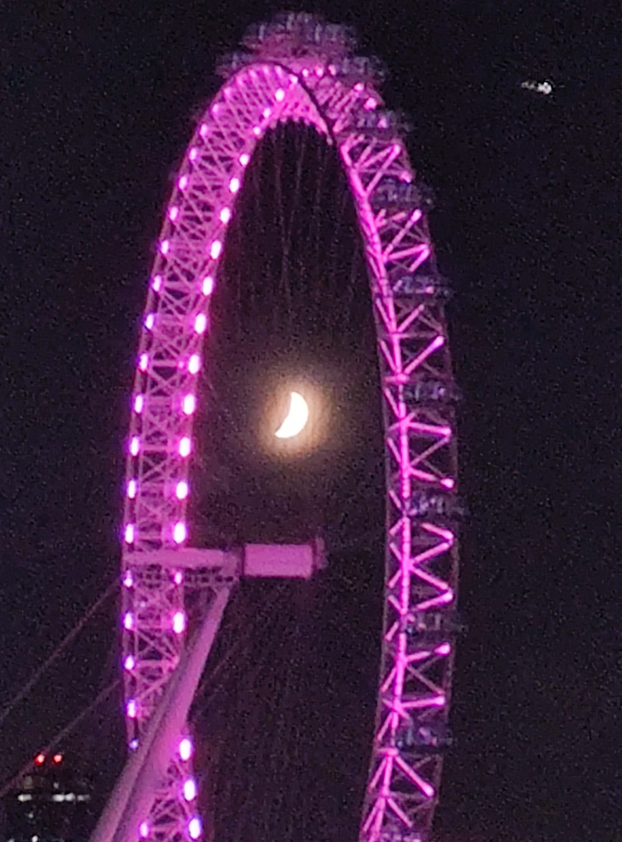

```python
from PIL import Image, ImageFilter
my_image = Image.open("EyeAndMoon.png")
# my_image = Image.open("Quad-Chaosheng-Zhang.png")
display(my_image)  # in some settings, use eye.show()
```

```python
print(f"Image is of type {my_image.format}, and size {my_image.size}")
```

```
Image is of type PNG, and size (622, 842)
```

[figure not shown]

```python
my_image_bw = my_image.convert("L")
display(my_image_bw)
```

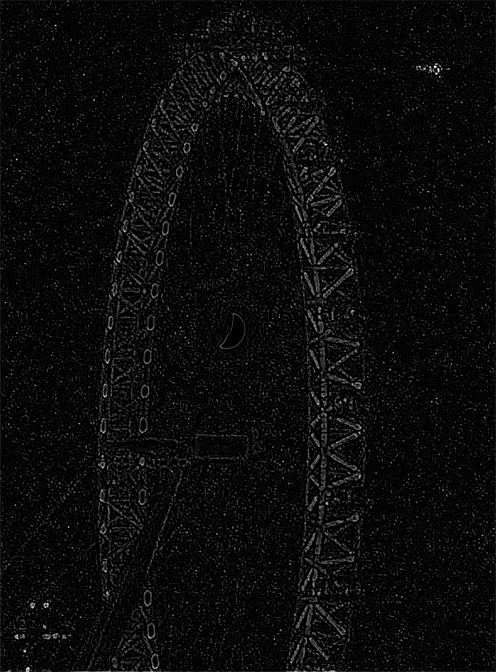

```python
my_image_bw.filter(ImageFilter.FIND_EDGES)
```

The PIL package has many more capabilities. For more, see https://pillow.readthedocs.io/en/stable/

## Taversing a list with a `for` loop

**`for` loops** work well with lists. One form of the `for` statement is

```
for <var> in <list>:
    <body>
```

It consists of a **heading** and a **body** The heading, between the keyword `for` and the colon (`:`) introduces a **loop variable** `<var>` and refers to a list `<list>`. The `<body>` is a consistently indented sequence of statements.

When executed, a `for` statement results in the execution of its `<body>` of statements once for each item of the list (in order). The particular item for each iteration is stored as the value of the variable `<var>`.

```python
numbers = [10, 3, -1, -11, 12]
numbers
```

```
[10, 3, -1, -11, 12]
```

```python
for item in numbers:
    print(item, end="--**--")
```

```
10--**--3--**---1--**---11--**--12--**--
```

Often we want to change items in the list. In the following example, we'll take a list of 1BS1 modules, and add a prefix of `2223-` to each code. For that we'll need to keep count of the items

```python
print(modules_in_1BS1)
```

```
['BO101', 'CH101', 'CS102', 'MA180', 'MA161', 'MP180', 'PH101', 'DS101']
```

```python
i = 0
for item in modules_in_1BS1:
    modules_in_1BS1[i]='2223-'+item
    i=i+1

print(modules_in_1BS1)
```

```
['2223-BO101', '2223-CH101', '2223-CS102', '2223-MA180', '2223-MA161', '2223-MP180', '2223-PH101', '2223-DS101']
```

### Map-Filter-Reduce

Most times we iterate through a list, we wish to preform some operation on the list. These operations are usually classed as one of **Map**. **Filter** or **Reduce**

- *MAP*: make a new list based on applying a formula/function to all values in a given list
- *FILTER*: make a sublist of those items that satisfy some criterion
- *REDUCE*: combine items in the list in some way

There are actually built-in functions to do these tasks, but we'll see first how to do them manually.

### A map function

We will write a function at adds one to every item in a list of numbers.

**IMPORTANT**: Unlike the methods we saw earlier, this function creates a new list: it does not change the old one.

```python
def add_one(my_list):
    new_list = []  # an empty list
    for item in my_list:
        new_list.append(item+1)
    return new_list
```

```python
numbers = [10, 3, -1, -11, 12]
print(f"<original> numbers = {numbers}")
numbers = add_one(numbers)
print(f"   <add 1> numbers = {numbers}")
```

```
<original> numbers = [10, 3, -1, -11, 12]
   <add 1> numbers = [11, 4, 0, -10, 13]
```

In this example, we'll modify strings in a list with a function that converts all strings in a list to upper-case.

```python
def upper_all(my_list):
    new_list = []  # empty list
    for item in my_list:
        new_list.append(item.upper())
    return new_list
```

```python
suits = ["HeartS", "DiAmOnDs", "clubs", "SPADES"]   # mixed case
print(f"Original list     = {suits}")
print(f"upper_all returns = {upper_all(suits)}")
```

```
Original list     = ['HeartS', 'DiAmOnDs', 'clubs', 'SPADES']
upper_all returns = ['HEARTS', 'DIAMONDS', 'CLUBS', 'SPADES']
```

**WARNING**: In these last two examples, and the next ones, I am being lazy. I should check that the data types for each item is correct, so that, for example, `item.upper()` makes sense.

### A filter function

We will write a function takes a list of numbers as arguments, and returns a list of the even ones.

```python
def even_list(my_list):
    new_list = []  # an empty list
    for item in my_list:
        if (item%2 == 0):  # is remainder on dividing by 2 is zero
            new_list.append(item)
    return new_list
```

```python
numbers = [10, 3, -1, 0 , -11, 0, 12]
print(f"<old> numbers = {numbers}")
```

```
<old> numbers = [10, 3, -1, 0, -11, 0, 12]
```

```python
even_numbers = even_list(numbers)
print(f" even numbers = {even_numbers}")
```

```
 even numbers = [10, 0, 0, 12]
```

In this filter example we'll make a sub-list of strings. The School of Mathematics and Statistical Sciences teaches modules in 1BS1 that start with the 'MA', 'MP' and 'CS' codes.

For that we will use the `in` operator. Just like for strings,

```
i in list_of_vals
```

evaluates as `True` if `i` is contained in the last, or `False` otherwise.

```python
print(numbers)
x = -12
x in numbers
```

```
[10, 3, -1, 0, -11, 0, 12]
```

```
False
```

```python
def maths_modules(my_list):
    mss_list = []  # an empty list
    for item in my_list:
        if (item[0:2] in ["MA", "CS", "MP"]):
            mss_list.append(item)
    return mss_list
```

```python
modules_in_1BS1 = ["BO101", "CH101", "CS102", "MA180", "MA161", "MP180", "PH101"]
mss_modules = maths_modules(modules_in_1BS1)
print(f"The modules in 1BS1 are {modules_in_1BS1}")
print(f"The ones taught by the School of Maths are {mss_modules}")
```

```
The modules in 1BS1 are ['BO101', 'CH101', 'CS102', 'MA180', 'MA161', 'MP180', 'PH101']
The ones taught by the School of Maths are ['CS102', 'MA180', 'MA161', 'MP180']
```

### A reduce function

A "reduce" operation combines elements in a list, usually to some single value. This usually makes use of an **accumulator** variable (very common in programing).

Example: suppose we want to compute the sum $$\sum_{i=1}^{10}i =1+2+\dotsb+9+10$$ of the numbers from $1$ to $10$.

One way to implement this in Python is to

- **initialise** an **accumulator variable** `total` with a value of $0$ and
- loop over the numbers 1, ..., 10 and add each to the accumulator.

```python
total = 0
for i in [1,2,3,4,5,6,7,8,9,10]:
    total = total + i
print(total)
```

```
55
```

A more common example is to compute the *mean* (usual "average") of number in a list.

```python
def mean(number_list):
    total = 0
    for i in number_list:
        total+=i
    return( total/len(number_list))
```

```python
nums = [1,3,-2,6,-5,9]
print(f"The mean of {nums} is {mean(nums)}")
```

```
The mean of [1, 3, -2, 6, -5, 9] is 2.0
```

Finished here Friday

## Ranges

Last week we met the built-in function `range()` that produces special objects corresponding to integer intervals.

- `range(stop)` returns the range 0, 1, ..., stop-1.
- `range(start, stop)` returns the range `start`, `start+1`, `start+2`, ... `stop-1)`
- `range(start, stop, step])` returns the range `start`, `start+step`, `start+2*step`, `start*3*step`, up to the largest possible value less than `stop`

```python
list(range(10,101,10))
```

```
[10, 20, 30, 40, 50, 60, 70, 80, 90, 100]
```

Ranges can be useful when operating on elements of a list, and where we want to change individual elements.

```python
nums = [1,2,-3,-4,5,6,-7,8]
print(f"nums={nums}")
for i in range(len(nums)):
    if (nums[i]<0):
        nums[i] *=-1

print(f"nums={nums}")
```

```
nums=[1, 2, -3, -4, 5, 6, -7, 8]
nums=[1, 2, 3, 4, 5, 6, 7, 8]
```

## List operations

### List addition

Earlier we saw that we can add one list to the end of another as follows:

```
list1 += list2
```

```python
list1 = ['i', 'ii', 'iii', 'iv', 'v']
list2 = [1, 2, 3, 4, 5]
list1 += list2
print(list1)
```

```
['i', 'ii', 'iii', 'iv', 'v', 1, 2, 3, 4, 5]
```

It is instructive to note that `list1 += list2` is just short-hand for `list1 = list1 + list2`. Therefore, we see that

- The plus operator can be used to add two list (i.e., add one to the end of another)
- The result is a new list, but we can give it a name using the assignment operator.

### List multiplication

We can use the `*` operator to repeat a list.

```python
list1 =  ['i', 'ii', 'iii', 'iv']
list2 = list1*3
print(list2)
```

```
['i', 'ii', 'iii', 'iv', 'i', 'ii', 'iii', 'iv', 'i', 'ii', 'iii', 'iv']
```

## What else?

There are many other methods and functions that can be applied to lists. See, e.g., https://docs.python.org/3/tutorial/datastructures.html

Here are a few of the most important:

### sorted() and sort()

To sort items in a list, you can use one of these methods:

- `sorted()` builtin function returns a new list what has the items of the old list, but sorted.
- `sort()` method modifies the list so that its items are sorted.

```python
python_terms = ['len', 'def', 'while', 'for', 'if', 'elif', 'else', 'list', 'dict']
print(python_terms)
print(sorted(python_terms))  # original list not changed
```

```
['len', 'def', 'while', 'for', 'if', 'elif', 'else', 'list', 'dict']
['def', 'dict', 'elif', 'else', 'for', 'if', 'len', 'list', 'while']
```

```python
print(python_terms)
python_terms.sort() # changes the list
print(python_terms)
```

```
['len', 'def', 'while', 'for', 'if', 'elif', 'else', 'list', 'dict']
['def', 'dict', 'elif', 'else', 'for', 'if', 'len', 'list', 'while']
```

### From list to strings to lists, and back again, with `join()` and `split()`

#### join()

The `join()` method applies to strings, taking a list as an argument, and returns a string. The string is used a a delimiter between members of the list.

```python
new_str = "--".join(python_terms)
print(new_str)
```

```
def--dict--elif--else--for--if--len--list--while
```

#### split()

To convert from a string with multiple words into a list, use `split()`.

Again, it is applied to a string, which will be split into items, takes a delimiter as argument, and returns a list.

```python
new_str.split('--')
```

```
['def', 'dict', 'elif', 'else', 'for', 'if', 'len', 'list', 'while']
```